# DDS_Project_JR_LM

Jeff Reed, Logan Miller

6/10/2021

# Reed and Miller Consulting has been hired by Budweiser to perform data analytics in order to aid in their business decision making process. We have received specific information regarding various types of beers as well as breweries in the United States which will be used to conduct our analysis. We have also been given specific questions that we will seek to answer and will also strive to report back other interesting insights that may be deemed pertinent and useful to their business.

# The code below is broken down into 2 categories. The information preceded by # is explanatory information while the other information located in the “code chunks” is the actual code used to perform our data analysis.

## Import Relevant Packages

```r
library(ggplot2)
library(magrittr)
library(dplyr)
library(GGally)
library(tibble)
library(class)
library(caret)
library(e1071)
library(readr)
library(ggthemes)
```

## Load Data

```r
Breweries = read.csv(file.choose())
Beers = read.csv(file.choose())
```

## Inspect Data

```r
head(Breweries)
```

```
##   Brew_ID                      Name          City State
## 1       1        NorthGate Brewing    Minneapolis    MN
## 2       2 Against the Grain Brewery    Louisville    KY
## 3       3  Jack's Abby Craft Lagers    Framingham    MA
## 4       4 Mike Hess Brewing Company     San Diego    CA
## 5       5   Fort Point Beer Company San Francisco    CA
## 6       6     COAST Brewing Company    Charleston    SC
```

```r
head(Beers)
```

```
##                              Name Beer_ID   ABV IBU Brewery_id
## 1             Chugach Session Ale     919 0.048  NA        494
## 2              Snowshoe White Ale     587 0.048  12        224
## 3          King Street Blonde Ale    1665 0.049  NA        103
## 4       Urban Wilderness Pale Ale      30 0.049  NA        558
## 5       Northern Lights Amber Ale     921 0.050  15        494
## 6 Peninsula Brewers Reserve (PBR)    1187 0.050  15        459
##                      Style Ounces
## 1                Cream Ale     12
## 2                  Witbier     12
## 3      American Blonde Ale     12
## 4         English Pale Ale     12
## 5 American Amber / Red Ale     12
## 6      American Blonde Ale     12
```

## Counting the breweries in each state

```r
Breweries %>% count(State, sort = TRUE)
```

```
##    State  n
## 1     CO 47
## 2     CA 39
## 3     MI 32
## 4     OR 29
## 5     TX 28
## 6     PA 25
## 7     MA 23
## 8     WA 23
## 9     IN 22
## 10    WI 20
## 11    NC 19
## 12    IL 18
## 13    NY 16
## 14    VA 16
```

[output cut: 37 more lines]

## Merging beer data with brewery data

```r
# Change column name in Brewery file to clarify names
Beers = Beers %>% rename(Beer_Name = Name, Brew_ID = Brewery_id)
colnames(Breweries)[2] = "Brewery_Name"
Beer_Brew_Combo = merge(Beers,Breweries,c("Brew_ID"))
```

## First and last 6 rows

```r
head(Beer_Brew_Combo, 6)
```

```
##   Brew_ID     Beer_Name Beer_ID   ABV IBU                               Style
## 1       1       Pumpion    2689 0.060  38                         Pumpkin Ale
## 2       1 Maggie's Leap    2691 0.049  26                  Milk / Sweet Stout
## 3       1   Parapet ESB    2687 0.056  47 Extra Special / Strong Bitter (ESB)
## 4       1    Stronghold    2688 0.060  25                     American Porter
## 5       1    Wall's End    2690 0.048  19                   English Brown Ale
## 6       1  Get Together    2692 0.045  50                        American IPA
##   Ounces       Brewery_Name        City State
## 1     16 NorthGate Brewing  Minneapolis    MN
## 2     16 NorthGate Brewing  Minneapolis    MN
## 3     16 NorthGate Brewing  Minneapolis    MN
## 4     16 NorthGate Brewing  Minneapolis    MN
## 5     16 NorthGate Brewing  Minneapolis    MN
## 6     16 NorthGate Brewing  Minneapolis    MN
```

```r
tail(Beer_Brew_Combo, 6)
```

```
##      Brew_ID                 Beer_Name Beer_ID   ABV IBU
## 2405     556             Pilsner Ukiah      98 0.055  NA
## 2406     557  Heinnieweisse Weissebier      52 0.049  NA
## 2407     557         Porkslap Pale Ale      49 0.043  NA
## 2408     557           Snapperhead IPA      51 0.068  NA
## 2409     557         Moo Thunder Stout      50 0.049  NA
## 2410     558 Urban Wilderness Pale Ale      30 0.049  NA
##                        Style Ounces                  Brewery_Name          City
## 2405         German Pilsener     12         Ukiah Brewing Company         Ukiah
## 2406              Hefeweizen     12       Butternuts Beer and Ale Garrattsville
## 2407 American Pale Ale (APA)     12       Butternuts Beer and Ale Garrattsville
## 2408            American IPA     12       Butternuts Beer and Ale Garrattsville
## 2409      Milk / Sweet Stout     12       Butternuts Beer and Ale Garrattsville
## 2410        English Pale Ale     12 Sleeping Lady Brewing Company     Anchorage
##      State
## 2405    CA
## 2406    NY
## 2407    NY
## 2408    NY
## 2409    NY
## 2410    AK
```

## Check missing values in each column

```r
sapply(Beer_Brew_Combo, function(x) sum(is.na(x)))
```

```
##      Brew_ID    Beer_Name      Beer_ID          ABV          IBU        Style
##            0            0            0           62         1005            0
##       Ounces Brewery_Name         City        State
##            0            0            0            0
```

## We can see that only the ABV and IBU columns have missing values.

## What will be done with this data?

## Randomness of NA’s warrants caution in removing all rows with NA’s

## NA’s will be removed only when we are analyzing data in the ABV and IBU columns

## Otherwise, we are removing valuable data unnecessarily

## Computing and plotting median ABV and IBU

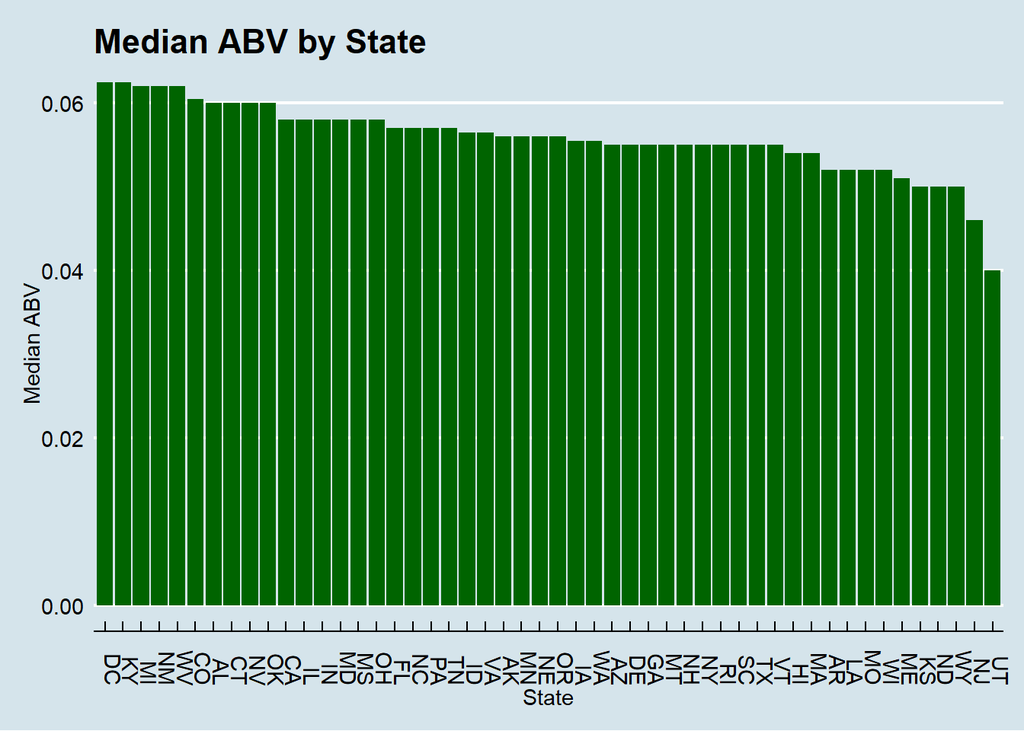

```r
BBC_Median_ABV = Beer_Brew_Combo %>% filter(!is.na(ABV)) %>% group_by(State) %>% summarise_at(vars(ABV),list(name = median)) %>% rename(Median_ABV = name)

BBC_Median_IBU = Beer_Brew_Combo %>% filter(!is.na(IBU)) %>% group_by(State) %>% summarise_at(vars(IBU),list(name = median)) %>% rename(Median_IBU = name)

ABV_IBU_Medians = merge(BBC_Median_ABV,BBC_Median_IBU,c("State"))

ABV_IBU_Medians %>%
  ggplot(aes(x = reorder(State, -Median_ABV,), y = Median_ABV)) +
  geom_bar(stat = 'identity', fill = 'dark green') +
  labs(x = 'State', y = 'Median ABV', title = 'Median ABV by State') +
  theme_economist() +
  theme(legend.position = 'none', axis.text.x = element_text(angle = 270, hjust = 1))
```

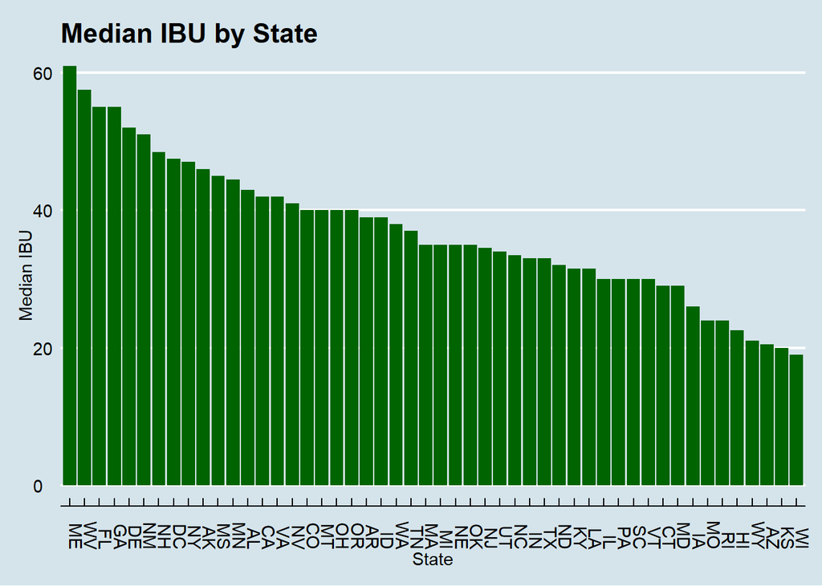

```r
ABV_IBU_Medians %>%
  ggplot(aes(x = reorder(State, -Median_IBU,), y = Median_IBU)) +
  geom_bar(stat = 'identity', fill = 'dark green') +
  labs(x = 'State', y = 'Median IBU', title = 'Median IBU by State') +
  theme_economist() +
  theme(legend.position = 'none', axis.text.x = element_text(angle = 270, hjust = 1))
```

## Which state has the maximum alcoholic beer? Which state has the most bitter beer?

```r
Beer_Brew_Combo %>% arrange(-ABV) %>% select(Beer_Name, ABV, State) %>% head(1)
```

```
##                                              Beer_Name   ABV State
## 1 Lee Hill Series Vol. 5 - Belgian Style Quadrupel Ale 0.128    CO
```

```r
Beer_Brew_Combo %>% arrange(-IBU) %>% select(Beer_Name, IBU, State) %>% head(1)
```

```
##                   Beer_Name IBU State
## 1 Bitter Bitch Imperial IPA 138    OR
```

### Colorado has the beer with the highest ABV at 0.128.

### Oregon has the beer with the highest IBU at 138.

## Comment on the summary statistic and distribution of the ABV variable

```r
summary(Beer_Brew_Combo$ABV)
```

```
##    Min. 1st Qu.  Median    Mean 3rd Qu.    Max.    NA's
## 0.00100 0.05000 0.05600 0.05977 0.06700 0.12800      62
```

```r
data.frame(Mean = round(mean(Beer_Brew_Combo$ABV, na.rm = TRUE), 3),
           Trimmed_Mean = round(mean(Beer_Brew_Combo$ABV, na.rm = TRUE, trim = 0.1), 3),
           Median = median(Beer_Brew_Combo$ABV, na.rm = TRUE),
           Standard_Deviation = round(sd(Beer_Brew_Combo$ABV, na.rm = TRUE), 3))
```

```
##   Mean Trimmed_Mean Median Standard_Deviation
## 1 0.06        0.058  0.056              0.014
```

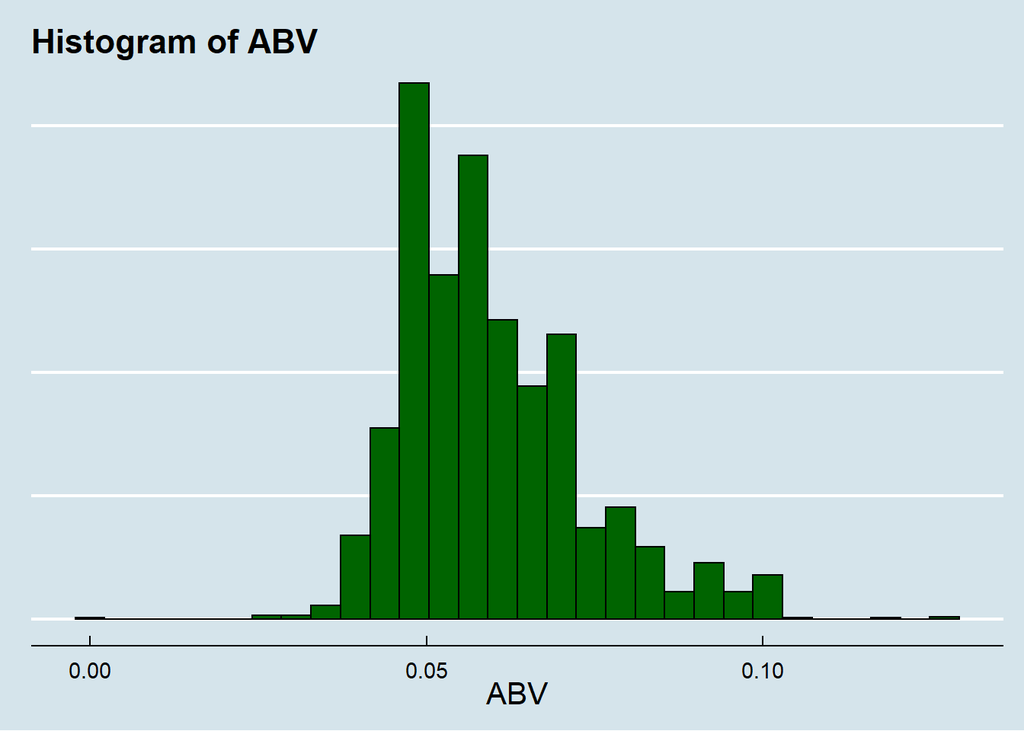

```r
Beer_Brew_Combo %>%
  ggplot(aes(x = ABV)) +
  geom_histogram(fill = 'dark green', color = 'black') +
  labs(x = 'ABV', y = '',  title = 'Histogram of ABV') +
  theme_economist() +
  theme(axis.text.y = element_blank(), axis.title.x = element_text(size = 15),legend.position = 'none')
```

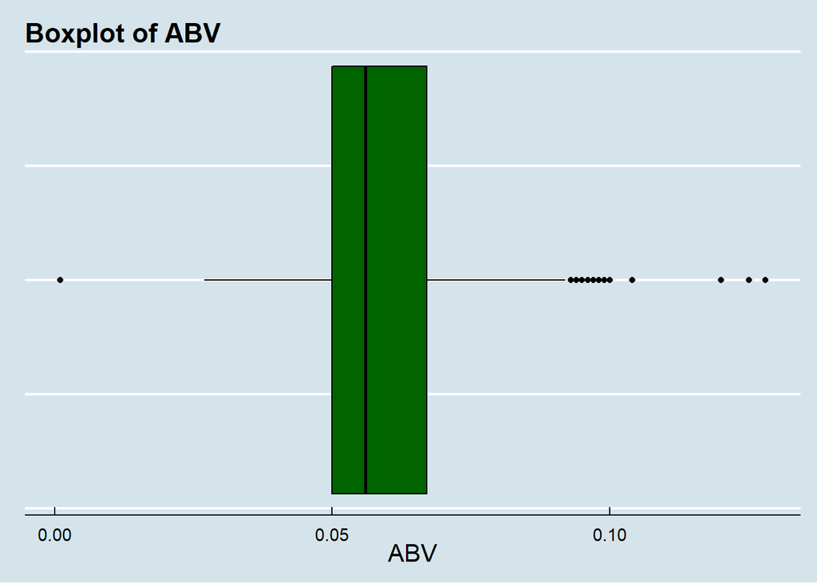

```r
Beer_Brew_Combo %>%
  ggplot(aes(x = ABV)) +
  geom_boxplot(fill = 'dark green', color = 'black') +
  labs(x = 'ABV', y = '',  title = 'Boxplot of ABV') +
  theme_economist() +
  theme(axis.text.y = element_blank(), axis.title.x = element_text(size = 15),legend.position = 'none')
```

## Is there a relationship between IBU and ABV?

```r
cor(x = Beer_Brew_Combo$IBU, y = Beer_Brew_Combo$ABV, method = 'pearson', use = 'na.or.complete')
```

```
## [1] 0.6706215
```

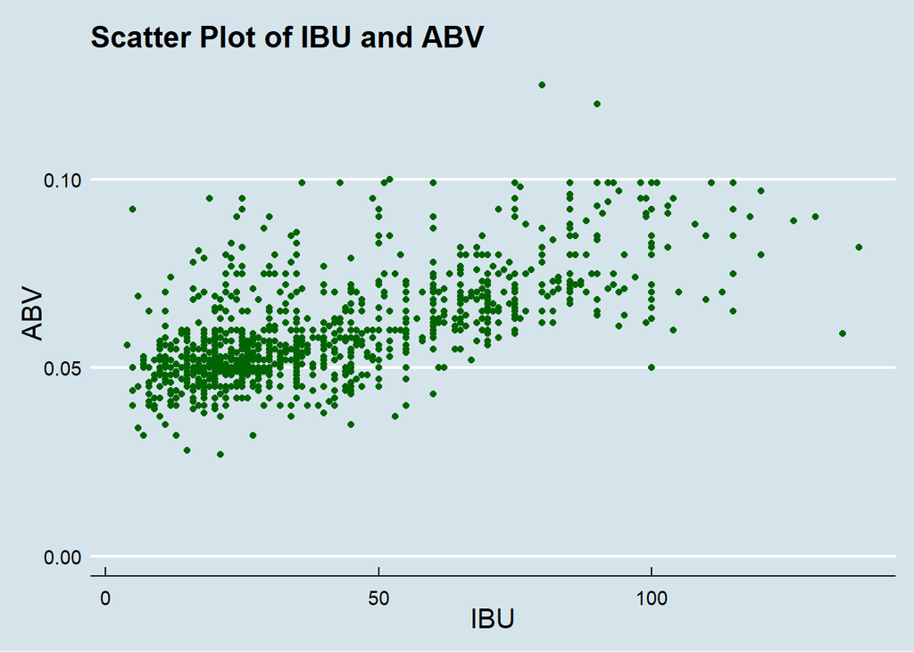

```r
Beer_Brew_Combo %>%
  ggplot(aes(x = IBU, y = ABV)) +
  geom_point(color = 'dark green') +
  labs(title = 'Scatter Plot of IBU and ABV') +
  theme_economist() +
  theme(axis.title.y = element_text(size = 15), axis.title.x = element_text(size = 15),legend.position = 'none')
```

### This is supported by a linear correlation coefficient of 0.67.

### Both of the graph and the correlation coefficient suggest that, in general, as IBU increases, so does ABV.

## Using KNN to investigate IBU vs ABV in IPAs and other Ales

### Deciding best K to use

```r
ipa_ale_df = Beer_Brew_Combo %>%
  filter(!is.na(ABV) &
           !is.na(IBU) &
           (grepl('\\bIPA\\b', Style, ignore.case = TRUE) | !grepl('\\bIPA\\b', Style) &
           grepl('\\bALE\\b', Style, ignore.case = TRUE))
         ) %>%
  mutate(isIPA = ifelse(grepl('\\bIPA\\b', Style, ignore.case = TRUE), 1, 0),
         scaled_ibu = scale(IBU),
         scaled_abv = scale(ABV)
    )

sample_size = floor(.70 * nrow(ipa_ale_df))

set.seed(67)

train_index = sample(seq_len(nrow(ipa_ale_df)), size = sample_size)

train_df = ipa_ale_df[train_index, ]
test_df = ipa_ale_df[-train_index, ]

accuracy_df = data.frame(accuracy = numeric(70), k = numeric(70))

for(i in 1:70)
{
  beer_classifications = knn(train_df[, c(12,13)],
                      test_df[, c(12,13)],
                      train_df$isIPA,
                      prob = TRUE, k = i)

  CM = confusionMatrix(table(beer_classifications, test_df$isIPA))

  accuracy_df$accuracy[i] = CM$overall[1]
  accuracy_df$k[i] = i

}
print(accuracy_df %>% arrange(-accuracy) %>% head())
```

```
##    accuracy  k
## 1 0.8732394  2
## 2 0.8732394 14
## 3 0.8697183 21
## 4 0.8661972  9
## 5 0.8661972 13
## 6 0.8661972 18
```

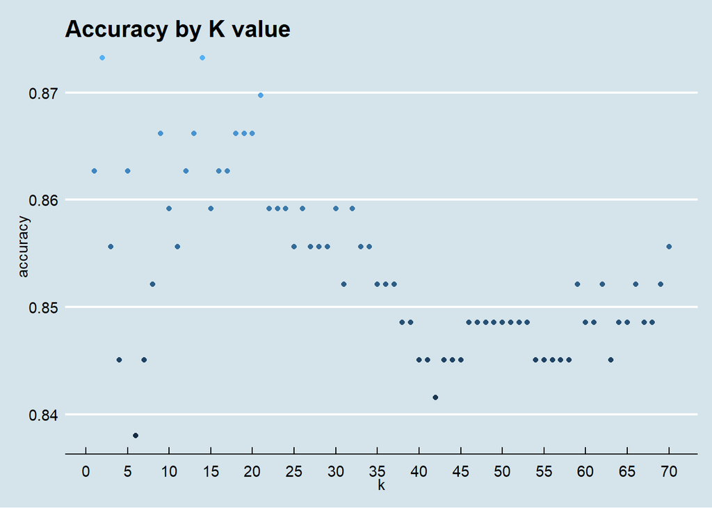

```r
accuracy_df %>%
  ggplot(aes(x = k, y = accuracy, color = accuracy)) +
  geom_point() +
  scale_x_continuous(breaks = seq(0, 70, 5)) +
  labs(title = 'Accuracy by K value') +
  theme_economist() +
  theme(legend.position = 'none')
```

### Highest accuracy occurs when k = 2 or 14, so we will go with 14

```r
set.seed(67)

classifications = knn(train_df[, c(12,13)],
                      test_df[, c(12,13)],
                      train_df$isIPA,
                      prob = TRUE, k = 14)

print(confusionMatrix(table(classifications, test_df$isIPA)))
```

```
## Confusion Matrix and Statistics
##
##
## classifications   0   1
##               0 144  19
##               1  17 104
##
##                Accuracy : 0.8732
##                  95% CI : (0.8289, 0.9096)
##     No Information Rate : 0.5669
##     P-Value [Acc > NIR] : <2e-16
##
##                   Kappa : 0.7414
##
##  Mcnemar's Test P-Value : 0.8676
##
##             Sensitivity : 0.8944
##             Specificity : 0.8455
##          Pos Pred Value : 0.8834
##          Neg Pred Value : 0.8595
##              Prevalence : 0.5669
##          Detection Rate : 0.5070
##    Detection Prevalence : 0.5739
##       Balanced Accuracy : 0.8700
##
##        'Positive' Class : 0
##
```

### Visualizing the above conculusion

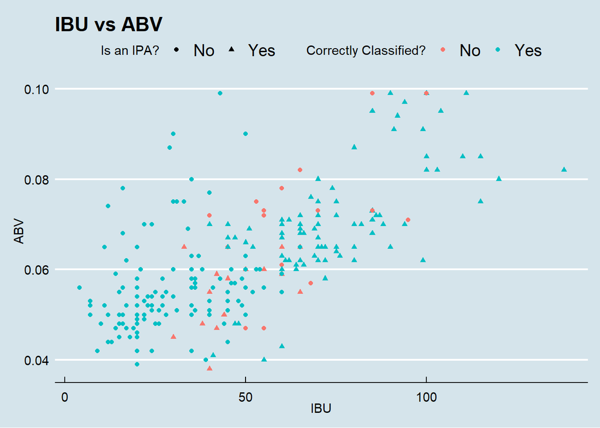

```r
test_df$classification = classifications


test_df = test_df %>%
  mutate(correct_classification = factor(ifelse(isIPA == classification, 1, 0), labels = c('No', 'Yes')),
         isIPA = factor(ifelse(isIPA == 1, 1, 0), labels = c('No', 'Yes')))

test_df %>%
  ggplot(aes(x = IBU, y = ABV, color = correct_classification)) +
  geom_point(aes(shape = isIPA)) +
  theme_economist() +
  labs(title = 'IBU vs ABV', color = 'Correctly Classified?', shape = 'Is an IPA?')
```

## Additional Insight for Budweiser:

### Question of interest: Given the beer market is very saturated in the US, what parts of the country should you think about prioritizing as it pertains to increasing sales penetration? Which region to focus on? And which states to focus on?

### Load the Region csv file which we pulled in from our database which we thought would be additive for our client and the info they provided

```r
Region = read.csv(file.choose(), header = TRUE)
summary(Region)
```

```
##     State              Region
##  Length:51          Length:51
##  Class :character   Class :character
##  Mode  :character   Mode  :character
```

### merge Breweries data frames with Region

```r
Brew_Region = merge(Breweries, Region,c("State"))
```

### Count breweries by region

```r
BR_R = Brew_Region %>% count(Region, sort = TRUE)
colnames(BR_R)[2] = "Breweries"
summary(BR_R)
```

```
##     Region            Breweries
##  Length:4           Min.   :102.0
##  Class :character   1st Qu.:119.2
##  Mode  :character   Median :134.0
##                     Mean   :139.5
##                     3rd Qu.:154.2
##                     Max.   :188.0
```

### Merge Beers data frames with Region

```r
Beer_State = select(Beer_Brew_Combo, Beer_ID, State)
Beers_Region = merge(Beer_State, Region,c("State"))
```

### Count beers by region

```r
BE_R = Beers_Region %>% count(Region, sort = TRUE)
colnames(BE_R)[2] = "Beers"
summary(BE_R)
```

```
##     Region              Beers
##  Length:4           Min.   :380.0
##  Class :character   1st Qu.:425.8
##  Mode  :character   Median :577.0
##                     Mean   :602.5
##                     3rd Qu.:753.8
##                     Max.   :876.0
```

### Merge dataframes together in order to calculate and assess beers to number of breweries ratio

```r
BR_BE_Region = merge(BR_R, BE_R, c("Region"))
BR_BE_Region$Beers_to_Breweries = BR_BE_Region$Beers / BR_BE_Region$Breweries
print(BR_BE_Region)
```

```
##             Region Breweries Beers Beers_to_Breweries
## 1   Midwest Region       143   713           4.986014
## 2 Northeast Region       102   380           3.725490
## 3     South Region       125   441           3.528000
## 4      West Region       188   876           4.659574
```

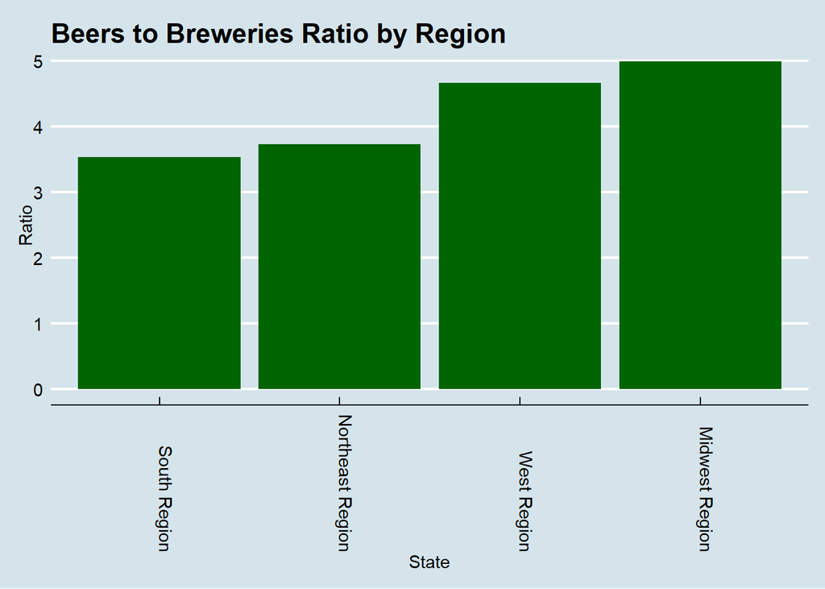

```r
BR_BE_Region %>%
  ggplot(aes(x = reorder(Region, Beers_to_Breweries), y = Beers_to_Breweries)) +
  geom_bar(stat = 'identity', fill = 'dark green') +
  labs(x = 'State', y = 'Ratio', title = 'Beers to Breweries Ratio by Region') +
  theme_economist() +
  theme(legend.position = 'none', axis.text.x = element_text(angle = 270, hjust = 1))
```

### Ratio of number of beers to number of breweries is most favorable in South Region thus we recommend to focusing new products in this less saturated market with favorable demographic trends

### Conduct similar analysis on a state basis within the South Region

```r
South_Beers = Beers_Region %>% filter(Region == "South Region")
summary(South_Beers)
```

```
##     State              Beer_ID        Region
##  Length:441         Min.   :  44   Length:441
##  Class :character   1st Qu.:1055   Class :character
##  Mode  :character   Median :1576   Mode  :character
##                     Mean   :1546
##                     3rd Qu.:2127
##                     Max.   :2686
```

```r
South_Brew = Brew_Region %>% filter(Region == "South Region")
summary(South_Brew)
```

```
##     State              Brew_ID      Brewery_Name           City
##  Length:125         Min.   :  2.0   Length:125         Length:125
##  Class :character   1st Qu.:157.0   Class :character   Class :character
##  Mode  :character   Median :270.0   Mode  :character   Mode  :character
##                     Mean   :287.8
##                     3rd Qu.:415.0
##                     Max.   :554.0
##     Region
##  Length:125
##  Class :character
##  Mode  :character
##
##
##
```

```r
BE_South = South_Beers %>% count(State, sort = TRUE)
colnames(BE_South)[2] = "Beers"
summary(BE_South)
```

```
##     State               Beers
##  Length:17          Min.   :  2.00
##  Class :character   1st Qu.:  8.00
##  Mode  :character   Median : 16.00
##                     Mean   : 25.94
##                     3rd Qu.: 21.00
##                     Max.   :130.00
```

```r
BR_South = South_Brew %>% count(State, sort = TRUE)
colnames(BR_South)[2] = "Breweries"
summary(BR_South)
```

```
##     State             Breweries
##  Length:17          Min.   : 1.000
##  Class :character   1st Qu.: 2.000
##  Mode  :character   Median : 4.000
##                     Mean   : 7.353
##                     3rd Qu.: 7.000
##                     Max.   :28.000
```

```r
BR_BE_South = merge(BR_South, BE_South, c("State"))
BR_BE_South$Beers_to_Breweries = BR_BE_South$Beers / BR_BE_South$Breweries
print(BR_BE_South)
```

```
##    State Breweries Beers Beers_to_Breweries
## 1     AL         3    10           3.333333
## 2     AR         2     5           2.500000
## 3     DC         1     8           8.000000
## 4     DE         2     2           1.000000
## 5     FL        15    58           3.866667
## 6     GA         7    16           2.285714
## 7     KY         4    21           5.250000
## 8     LA         5    19           3.800000
## 9     MD         7    21           3.000000
## 10    MS         2    11           5.500000
## 11    NC        19    59           3.105263
## 12    OK         6    19           3.166667
## 13    SC         4    14           3.500000
## 14    TN         3     6           2.000000
## 15    TX        28   130           4.642857
## 16    VA        16    40           2.500000
## 17    WV         1     2           2.000000
```

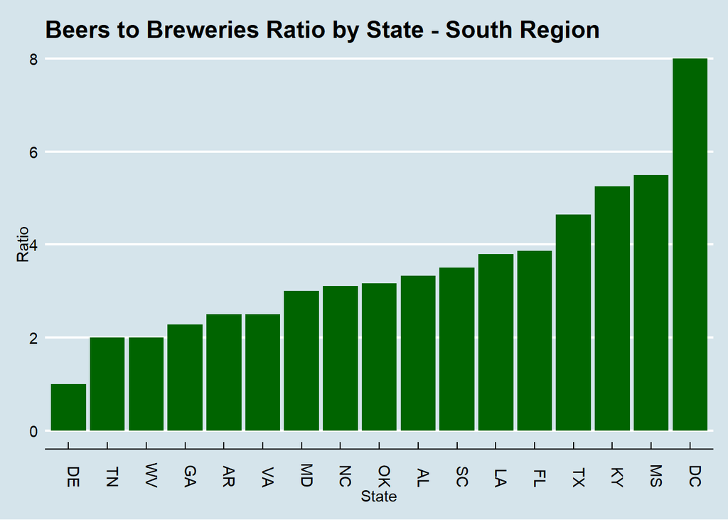

```r
BR_BE_South %>%
  ggplot(aes(x = reorder(State, Beers_to_Breweries), y = Beers_to_Breweries)) +
  geom_bar(stat = 'identity', fill = 'dark green') +
  labs(x = 'State', y = 'Ratio', title = 'Beers to Breweries Ratio by State - South Region') +
  theme_economist() +
  theme(legend.position = 'none', axis.text.x = element_text(angle = 270, hjust = 1))
```

```r
write.table(BR_BE_South, "clipboard", sep="\t", row.names=FALSE)
```

## Considering Beers to Breweries ratio and number of breweries, we recommend initially focusing sales penetration efforts on North Caroline and Virginia.